# Aircrafts used in World War 2

Henriette Stenius Wohlin

2022-12-06, updated 02 januar, 2023

## Setup

```r
library(tidyverse)
```

Making data frame:

```r
aircrafts_ww2 <- read.csv("data/world_war_2_aircrafts.csv")
```

## Cleaning data

Changing column names

```r
colnames(aircrafts_ww2)[1] = "Aircraft_type"
colnames(aircrafts_ww2)[2] = "Aircraft_subtype"
colnames(aircrafts_ww2)[3] = "Aircraft_name"
colnames(aircrafts_ww2)[4] = "Year_service"
colnames(aircrafts_ww2)[5] = "Country"
```

Source: https://sparkbyexamples.com/r-programming/rename-column-in-r/

Problem: n/a, blank and 1 1930s in Year_service column. We need to fix that in order to change Year_ service column to a numeric one.

```r
aircrafts_ww2$Year_service <- str_replace(aircrafts_ww2$Year_service, "s", "")
```

Source: https://sparkbyexamples.com/r-programming/r-str_replace-to-replace-matched-patterns-in-a-string/

```r
aircrafts_ww2$Year_service <- str_replace(aircrafts_ww2$Year_service, "n/a", "")
```

Replacing blank with NA:

```r
aircrafts_ww2[aircrafts_ww2 == ""] <- NA
```

Source: https://statisticsglobe.com/replace-blank-by-na-in-r

```r
aircrafts_ww2$Country <- str_replace(aircrafts_ww2$Country, "Germany, Japan", "Japan")
```

Now I can change the Year_service column to a numeric one:

```r
aircrafts_ww2$Year_service <- as.numeric(as.character(aircrafts_ww2$Year_service))
```

Source: https://stackoverflow.com/questions/37707060/converting-data-frame-column-from-character-to-numeric

## Visualizing every aircraft in dataset

First I would like to make a visualization of every aircraft in the data set to find out which has the highest count.

Let’s try to count every aircraft first:

```r
aircrafts_ww2 %>%
  select(Aircraft_type) %>%
  count(Aircraft_type, sort = TRUE)
```

```
##                                  Aircraft_type   n
## 1                                   Prototypes 292
## 2                   Bomber and Attack aircraft 189
## 3               Transport and Utility aircraft 178
## 4                                     Trainers 151
## 5                             Fighter aircraft 147
## 6                                    Seaplanes 127
## 7                                     Research  32
## 8  Strategic and Photo-reconnaissance aircraft  30
## 9                           Rockets and Drones  15
## 10                                  Rotorcraft   8
## 11                                      Blimps   4
## 12                               Misc research   3
```

“Strategic and photo-reconnaissance aircraft” is a long name so I am changing it to “Strat. and Photo-recon. aircraft”:

```r
aircrafts_ww2$Aircraft_type <- gsub("Strategic and Photo-reconnaissance aircraft", "Strat. and Photo-recon. aircraft", aircrafts_ww2$Aircraft_type)
```

Source: https://stackoverflow.com/questions/50615116/renaming-character-variables-in-a-column-in-data-frame-r

Now I can visualize how many of the different types of aircrafts that there are in the data set:

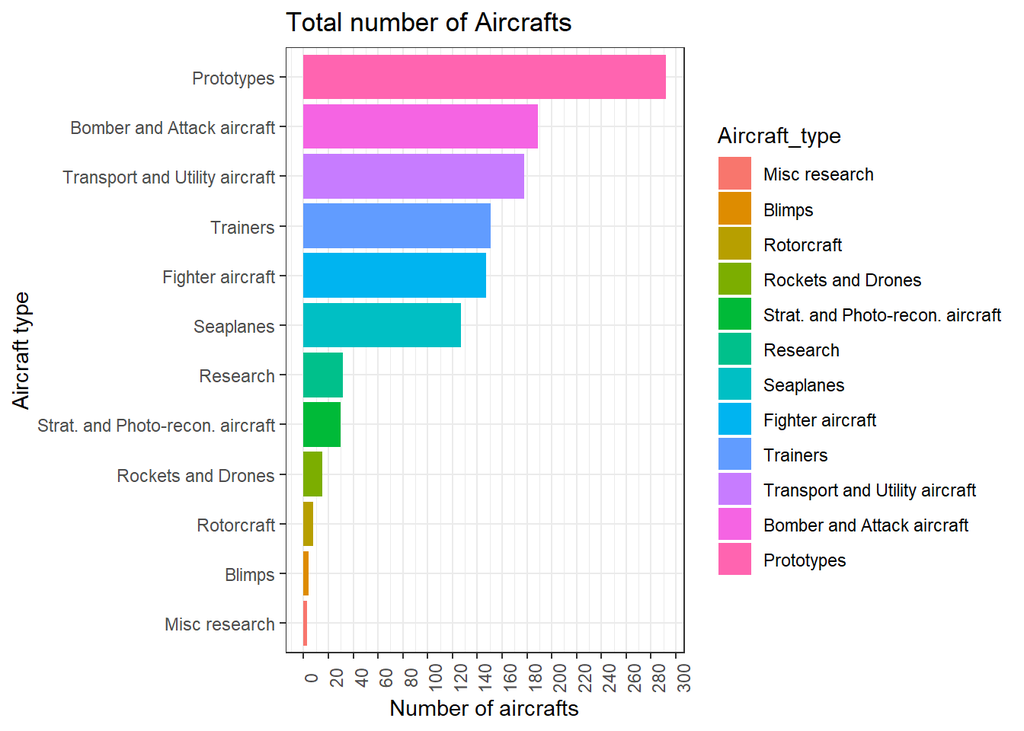

```r
aircrafts_ww2 %>%
  select(Aircraft_type) %>%
  count(Aircraft_type, sort = TRUE) %>%
  mutate(Aircraft_type = fct_reorder(Aircraft_type, n)) %>%
  ggplot(aes(x = n, y = Aircraft_type, fill=Aircraft_type)) +
  geom_col() +
  theme_bw() +
  labs(title = "Total number of Aircrafts",
       y = "Aircraft type",
       x = "Number of aircrafts") +
  scale_x_continuous(breaks=seq(0,300,20)) +
  theme(axis.text.x = element_text(angle = 90))
```

Source for fct_reorder code: https://r-graph-gallery.com/267-reorder-a-variable-in-ggplot2.html

From this data we can see that Prototypes have the highest count by a lot.

However, on the Wikipedia page it says that Prototypes aircrafts was intended to enter service but did not. Research Aircraft was intended to prove a concept or an idea but was also not suitable for military service. Trainers also did not enter active combat.

I would then like to make some visualization of of the aircrafts actually used during the war.

## Visualizing aircrafts used in WW2

Let us start by counting the aircrafts once more.

```r
aircrafts_ww2 %>%
  filter(Aircraft_type %in% c("Fighter aircraft", "Bomber and Attack aircraft", "Seaplanes", "Transport and Utility aircraft", "Rotorcraft", "Blimps", "Rockets and Drones", "Strat. and Photo-recon aircraft","Trainers")) %>%
  count(Aircraft_type, sort = TRUE)
```

```
##                    Aircraft_type   n
## 1     Bomber and Attack aircraft 189
## 2 Transport and Utility aircraft 178
## 3                       Trainers 151
## 4               Fighter aircraft 147
## 5                      Seaplanes 127
## 6             Rockets and Drones  15
## 7                     Rotorcraft   8
## 8                         Blimps   4
```

Now let us try to visualize it:

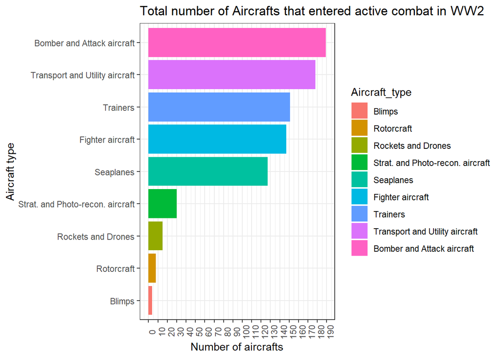

```r
aircrafts_ww2 %>%
  filter(Aircraft_type %in% c("Fighter aircraft", "Bomber and Attack aircraft", "Seaplanes", "Transport and Utility aircraft", "Rotorcraft", "Blimps", "Rockets and Drones", "Strat. and Photo-recon. aircraft","Trainers")) %>%
  count(Aircraft_type, sort = TRUE) %>%
  mutate(Aircraft_type = fct_reorder(Aircraft_type, n)) %>%
  ggplot(aes(x = n, y = Aircraft_type, fill=Aircraft_type)) +
  geom_col() +
  theme_bw() +
  labs(title = "Total number of Aircrafts that entered active combat in WW2",
       y = "Aircraft type",
       x = "Number of aircrafts") +
  scale_x_continuous(breaks=seq(0,200,10)) +
  theme(axis.text.x = element_text(angle = 90))
```

Bomber and Attack aircrafts looks like to be the highest with Transport and Utility aircrafts close behind. Rockets & Drones, Rotercrafts and Blimps are the lowest.

## Visualizing aircrafts not in active service during WW2

Now let us look at aircrafts not in service during the war. I repeat what I did before:

```r
aircrafts_ww2 %>%
  filter(Aircraft_type %in% c("Prototypes", "Research", "Misc research")) %>%
  count(Aircraft_type, sort = TRUE)
```

```
##   Aircraft_type   n
## 1    Prototypes 292
## 2      Research  32
## 3 Misc research   3
```

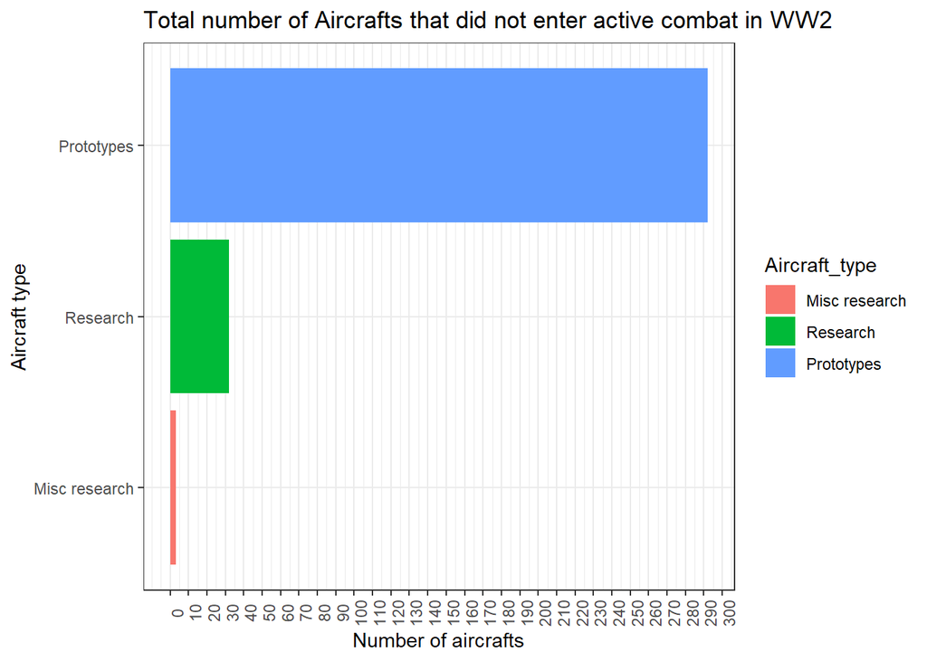

```r
aircrafts_ww2 %>%
  filter(Aircraft_type %in% c("Prototypes", "Research", "Misc research")) %>%
  count(Aircraft_type, sort = TRUE) %>%
  mutate(Aircraft_type = fct_reorder(Aircraft_type, n)) %>%
  ggplot(aes(x = n, y = Aircraft_type, fill=Aircraft_type)) +
  geom_col() +
  theme_bw() +
  labs(title = "Total number of Aircrafts that did not enter active combat in WW2",
       y = "Aircraft type",
       x = "Number of aircrafts") +
  scale_x_continuous(breaks=seq(0,300,10)) +
  theme(axis.text.x = element_text(angle = 90))
```

From this we can again see that prototypes has a high count.

## Aircrafts and origin of Country

Now I would like to look at which country produced the most aircrafts.

First we can try for every aircraft:

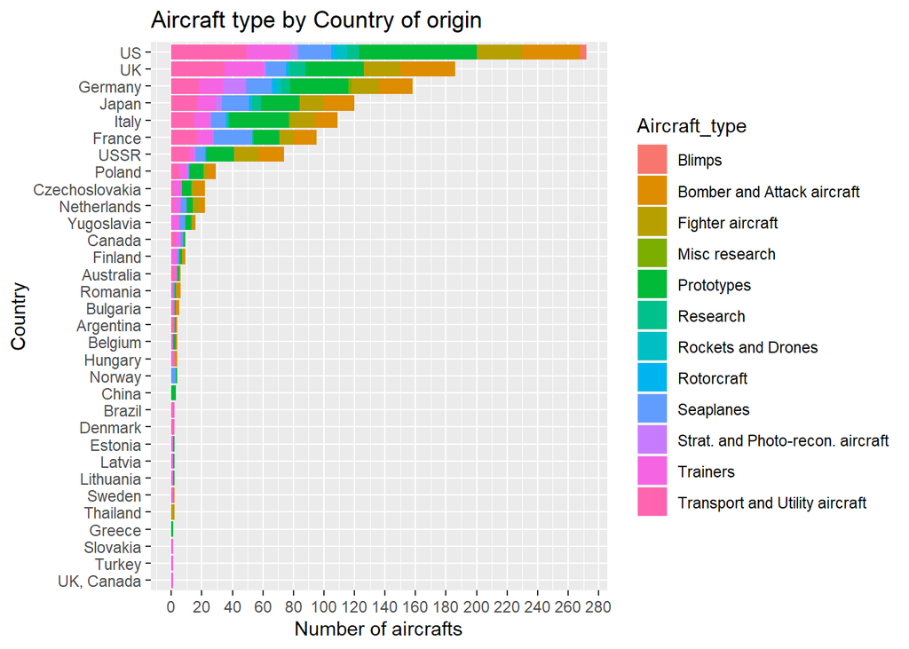

```r
aircrafts_ww2 %>%
  drop_na(Country) %>%
  ggplot(aes(x = fct_rev(fct_infreq(Country)))) +
  geom_bar(aes(fill = Aircraft_type), alpha = 5) +
  coord_flip() +
  labs(title = "Aircraft type by Country of origin",
       y = "Number of aircrafts",
       x = "Country") +
  scale_y_continuous(breaks=seq(0,300,20))
```

I would like to compare the biggest participants of aircrafts in World War 2, so I will sort it even more:

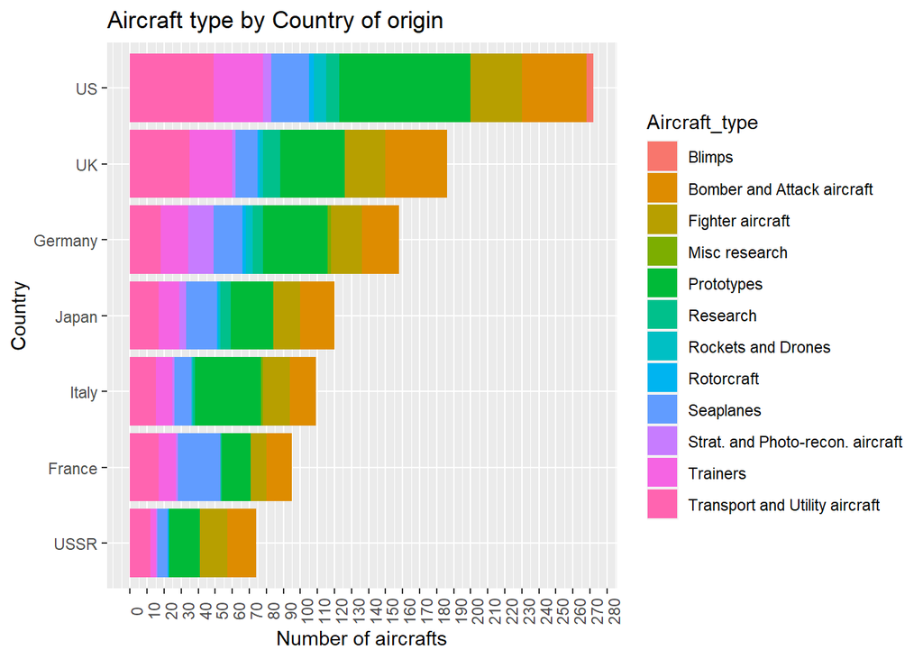

```r
aircrafts_ww2 %>%
  filter(Country %in% c ("US", "UK", "Germany", "Japan", "France", "USSR", "Italy")) %>%
  drop_na(Country) %>%
  ggplot(aes(x = fct_rev(fct_infreq(Country)))) +
  geom_bar(aes(fill = Aircraft_type), alpha = 5) +
  coord_flip() +
  labs(title = "Aircraft type by Country of origin",
       y = "Number of aircrafts",
       x = "Country") +
    scale_y_continuous(breaks=seq(0,300,10)) +
  theme(axis.text.x = element_text(angle = 90))
```

However, this is very hard to make sense of so I will split the aircrafts again between if it was in service during the war or not.

## Aircrafts that entered active combat and Country of origin

We will start with aircrafts that entered active combat during WW2:

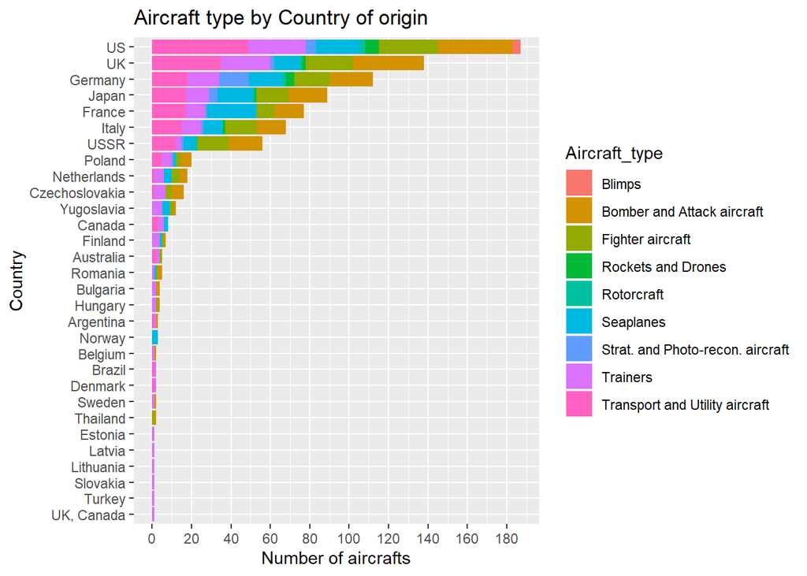

```r
aircrafts_ww2 %>%
  filter(Aircraft_type %in% c("Fighter aircraft", "Bomber and Attack aircraft", "Seaplanes", "Transport and Utility aircraft", "Rotorcraft", "Blimps", "Rockets and Drones", "Strat. and Photo-recon. aircraft","Trainers")) %>%
  drop_na(Country) %>%
  ggplot(aes(x = fct_rev(fct_infreq(Country)))) +
  geom_bar(aes(fill = Aircraft_type), alpha = 5) +
  coord_flip() +
  labs(title = "Aircraft type by Country of origin",
       y = "Number of aircrafts",
       x = "Country") +
  scale_y_continuous(breaks=seq(0,180,20))
```

Now let us sort it again by the big participants:

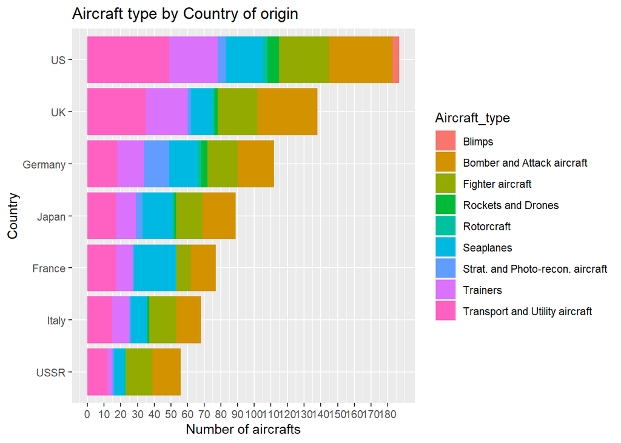

```r
aircrafts_ww2 %>%
  filter(Aircraft_type %in% c("Fighter aircraft", "Bomber and Attack aircraft", "Seaplanes", "Transport and Utility aircraft", "Rotorcraft", "Blimps", "Rockets and Drones", "Strat. and Photo-recon. aircraft","Trainers")) %>%
  filter(Country %in% c ("US", "UK", "Germany", "Japan", "France", "USSR", "Italy")) %>%
  drop_na(Country) %>%
  ggplot(aes(x = fct_rev(fct_infreq(Country)))) +
  geom_bar(aes(fill = Aircraft_type), alpha = 5) +
  coord_flip() +
  labs(title = "Aircraft type by Country of origin",
       y = "Number of aircrafts",
       x = "Country") +
    scale_y_continuous(breaks=seq(0,180,10))
```

## Aircrafts not in active service during WW2 and origin of Country

Let us enter the same code as before but with the aircrafts not in active service:

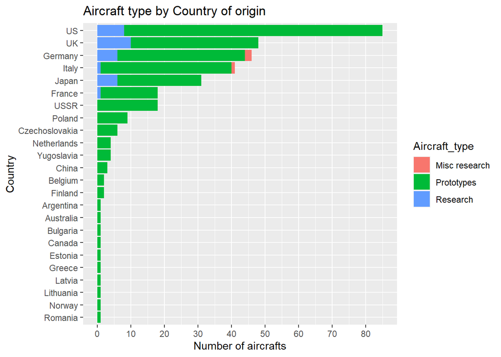

```r
aircrafts_ww2 %>%
  filter(Aircraft_type %in% c("Prototypes", "Research", "Misc research")) %>%
  drop_na(Country) %>%
  ggplot(aes(x = fct_rev(fct_infreq(Country)))) +
  geom_bar(aes(fill = Aircraft_type), alpha = 5) +
  coord_flip() +
  labs(title = "Aircraft type by Country of origin",
       y = "Number of aircrafts",
       x = "Country") +
  scale_y_continuous(breaks=seq(0,120,10))
```

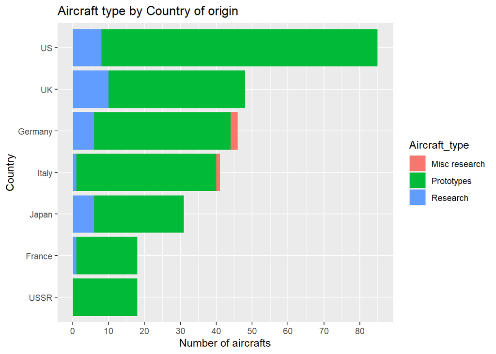

```r
aircrafts_ww2 %>%
  filter(Aircraft_type %in% c("Prototypes", "Research", "Misc research")) %>%
  filter(Country %in% c ("US", "UK", "Germany", "Japan", "France", "USSR", "Italy")) %>%
  drop_na(Country) %>%
  ggplot(aes(x = fct_rev(fct_infreq(Country)))) +
  geom_bar(aes(fill = Aircraft_type), alpha = 5) +
  coord_flip() +
  labs(title = "Aircraft type by Country of origin",
       y = "Number of aircrafts",
       x = "Country") +
  scale_y_continuous(breaks=seq(0,120,10))
```

## All Aircrafts and Year in service

This time I would like to examine the different types of aircrafts and the year that they entered service which means the year the aircraft had its first flight.

First let us count them:

```r
aircrafts_ww2 %>%
  select(Year_service) %>%
  count(Year_service, sort = TRUE)
```

```
##    Year_service   n
## 1          1940 113
## 2          1942 105
## 3          1941 103
## 4          1938  97
## 5          1939  92
## 6          1943  86
## 7          1944  86
## 8          1937  84
## 9          1935  77
## 10         1936  60
## 11         1945  58
## 12         1934  42
## 13         1933  35
## 14         1931  30
## 15         1932  27
## 16         1930  17
## 17         1926  13
## 18         1928  11
## 19         1929  11
## 20         1925   8
## 21         1927   8
## 22         1924   5
## 23           NA   3
## 24         1913   1
## 25         1920   1
## 26         1921   1
## 27         1922   1
## 28         1923   1
```

1940 is the highest year that aircrafts had their first flight, followed by 1942 and 1941.

Now let us try to visualize it as we have done before with every aircraft:

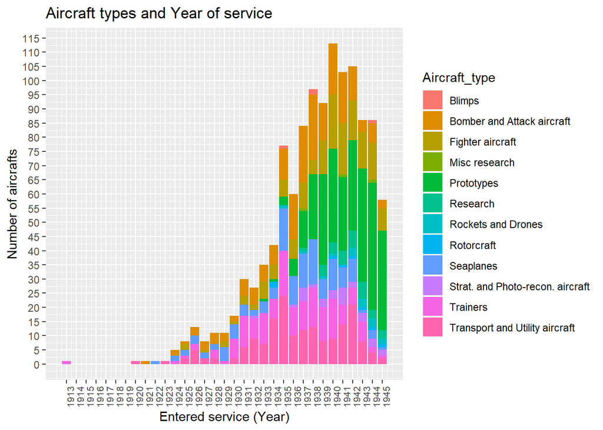

```r
aircrafts_ww2 %>%
  drop_na(Year_service) %>%
  ggplot(aes(x = Year_service)) +
  geom_bar(aes(fill = Aircraft_type)) +
  labs(title = "Aircraft types and Year of service",
       y = "Number of aircrafts",
       x = "Entered service (Year)") +
    scale_y_continuous(breaks=seq(0,120,5)) +
    scale_x_continuous(breaks=seq(1913,1945,1)) +
    theme(axis.text.x = element_text(angle = 90)) +
    theme(axis.text.x = element_text(size = 8))
```

I would like to try and compare the interwar period and World War 2 to see if there is a difference.

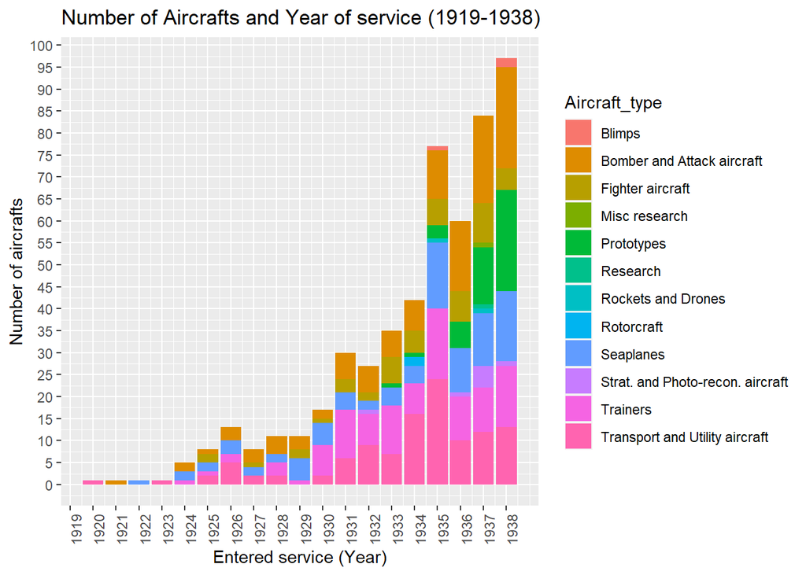

```r
aircrafts_ww2 %>%
  drop_na(Year_service) %>%
  filter(Year_service %in% c("1919","1920", "1921", "1922", "1923", "1924", "1925", "1926", "1926", "1927", "1928", "1929", "1930","1931","1932","1933", "1934","1935", "1936", "1937","1938")) %>%
  ggplot(aes(x = Year_service)) +
  geom_bar(aes(fill = Aircraft_type)) +
  labs(title = "Number of Aircrafts and Year of service (1919-1938)",
       y = "Number of aircrafts",
       x = "Entered service (Year)") +
    scale_y_continuous(breaks=seq(0,120,5)) +
    scale_x_continuous(breaks=seq(1919,1938,1)) +
    theme(axis.text.x = element_text(angle = 90))
```

World War 2 (1939-1945):

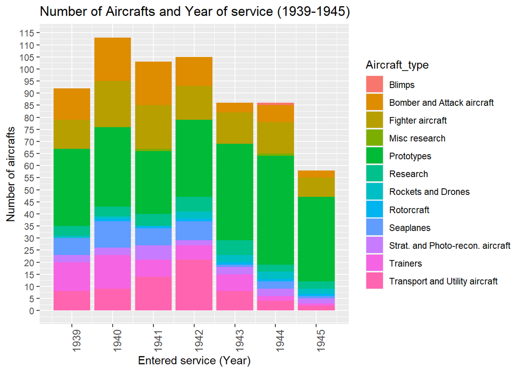

```r
aircrafts_ww2 %>%
  drop_na(Year_service) %>%
  filter(Year_service %in% c("1939", "1940", "1941", "1942", "1943", "1944", "1945")) %>%
  ggplot(aes(x = Year_service)) +
  geom_bar(aes(fill = Aircraft_type)) +
  labs(title = "Number of Aircrafts and Year of service (1939-1945)",
       y = "Number of aircrafts",
       x = "Entered service (Year)") +
    scale_y_continuous(breaks=seq(0,120,5)) +
    scale_x_continuous(breaks=seq(1939,1945,1)) +
    theme(axis.text.x = element_text(angle = 90)) +
    theme(axis.text.x = element_text(size = 10))
```

However once again, this visualization is a bit hard to understand and look at because there are so many aircrafts. Let’s split the aircrafts once more.

## Aircrafts that entered active combat and Year of Service

Aircrafts that entered active combat and what year of service they had:

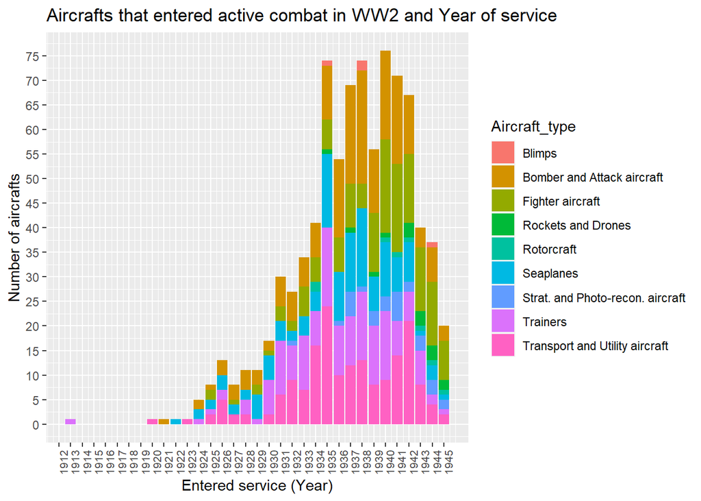

```r
aircrafts_ww2 %>%
  drop_na(Year_service) %>%
  filter(Aircraft_type %in% c("Fighter aircraft", "Bomber and Attack aircraft", "Seaplanes", "Transport and Utility aircraft", "Rotorcraft", "Blimps", "Rockets and Drones", "Strat. and Photo-recon. aircraft", "Trainers")) %>%
  ggplot(aes(x = Year_service)) +
  geom_bar(aes(fill = Aircraft_type)) +
  labs(title = "Aircrafts that entered active combat in WW2 and Year of service",
       y = "Number of aircrafts",
       x = "Entered service (Year)") +
    scale_y_continuous(breaks=seq(0,120,5)) +
    scale_x_continuous(breaks=seq(1912,1945,1)) +
    theme(axis.text.x = element_text(angle = 90)) +
    theme(axis.text.x = element_text(size = 8))
```

Still this can be a difficult to make sense of as there is so many years.

To make it easier I would like to split the years between the interwar period from 1919-1938 and World War 2 1939-1945.

Interwar period (1919-1938):

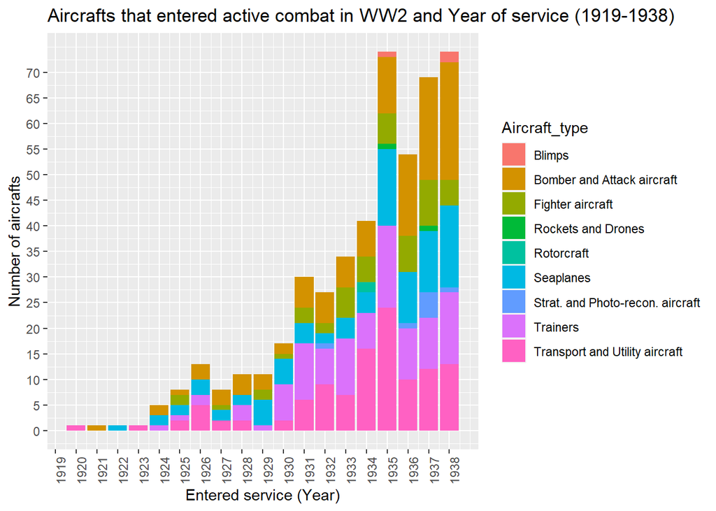

```r
aircrafts_ww2 %>%
  drop_na(Year_service) %>%
  filter(Year_service %in% c("1919","1920", "1921", "1922", "1923", "1924", "1925", "1926", "1926", "1927", "1928", "1929", "1930","1931","1932","1933", "1934","1935", "1936", "1937","1938")) %>%
  filter(Aircraft_type %in% c("Fighter aircraft", "Bomber and Attack aircraft", "Seaplanes", "Transport and Utility aircraft", "Rotorcraft", "Blimps", "Rockets and Drones", "Strat. and Photo-recon. aircraft", "Trainers")) %>%
  ggplot(aes(x = Year_service)) +
  geom_bar(aes(fill = Aircraft_type)) +
  labs(title = "Aircrafts that entered active combat in WW2 and Year of service (1919-1938)",
       y = "Number of aircrafts",
       x = "Entered service (Year)") +
    scale_y_continuous(breaks=seq(0,70,5)) +
    scale_x_continuous(breaks=seq(1919,1938,1)) +
    theme(axis.text.x = element_text(angle = 90))
```

World War 2 (1939-1945):

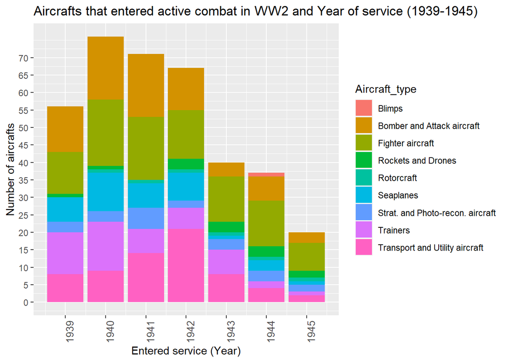

```r
aircrafts_ww2 %>%
  drop_na(Year_service) %>%
  filter(Year_service %in% c("1939", "1940", "1941", "1942", "1943", "1944", "1945")) %>%
  filter(Aircraft_type %in% c("Fighter aircraft", "Bomber and Attack aircraft", "Seaplanes", "Transport and Utility aircraft", "Rotorcraft", "Blimps", "Rockets and Drones", "Strat. and Photo-recon. aircraft", "Trainers")) %>%
  ggplot(aes(x = Year_service)) +
  geom_bar(aes(fill = Aircraft_type)) +
  labs(title = "Aircrafts that entered active combat in WW2 and Year of service (1939-1945)",
       y = "Number of aircrafts",
       x = "Entered service (Year)") +
    scale_y_continuous(breaks=seq(0,70,5)) +
    scale_x_continuous(breaks=seq(1939,1945,1)) +
    theme(axis.text.x = element_text(angle = 90)) +
    theme(axis.text.x = element_text(size = 10))
```

From 1940-1942 there definitely was more aircrafts that entered service compared to the other years. As it got closer to World War 2 there was more aircrafts made.

## Aircrafts not in active service during WW2 and Year in Service

Now let us repeat the process we just did but with aircrafts not in active service:

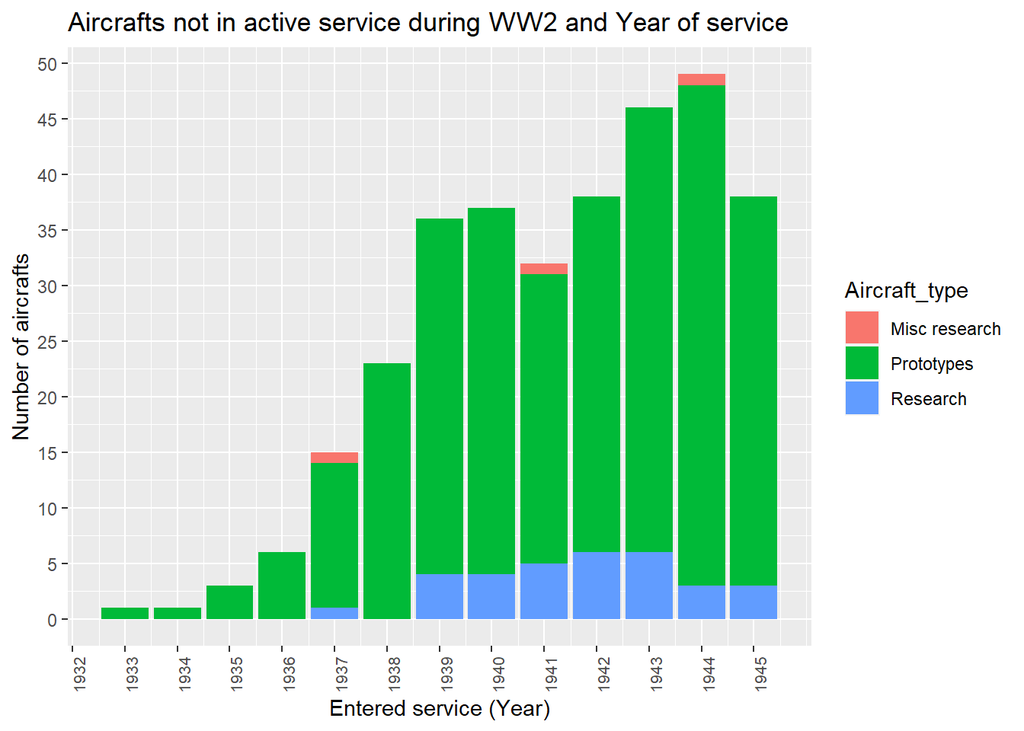

```r
aircrafts_ww2 %>%
  drop_na(Year_service) %>%
  filter(Aircraft_type %in% c("Prototypes", "Research", "Misc research")) %>%
  ggplot(aes(x = Year_service)) +
  geom_bar(aes(fill = Aircraft_type)) +
  labs(title = "Aircrafts not in active service during WW2 and Year of service",
       y = "Number of aircrafts",
       x = "Entered service (Year)") +
    scale_y_continuous(breaks=seq(0,55,5)) +
    scale_x_continuous(breaks=seq(1912,1945,1)) +
    theme(axis.text.x = element_text(angle = 90)) +
    theme(axis.text.x = element_text(size = 8))
```

Let us split the years once more:

Interwar period (1919-1938):

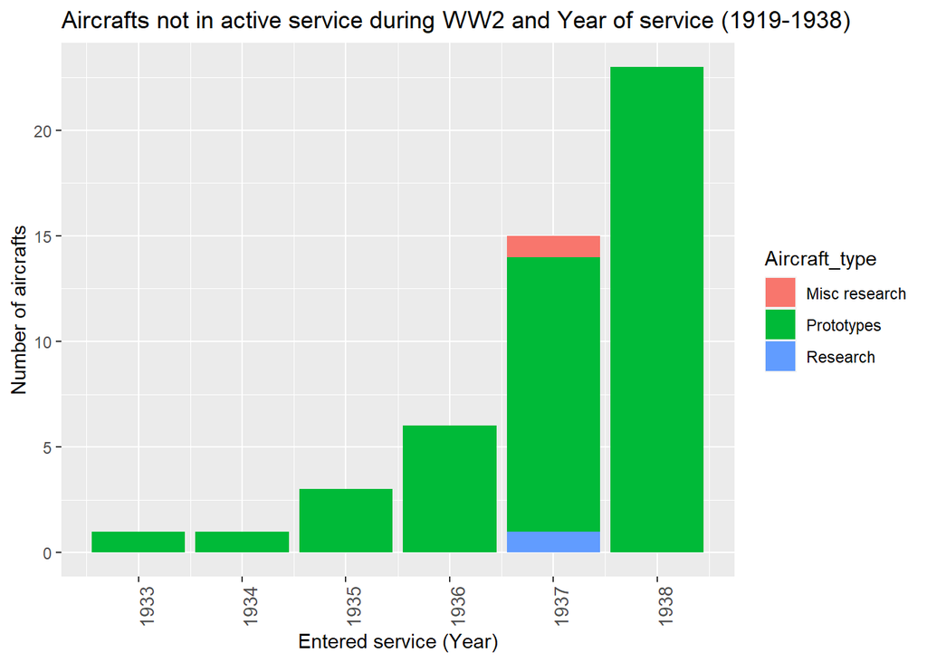

```r
aircrafts_ww2 %>%
  drop_na(Year_service) %>%
  filter(Aircraft_type %in% c("Prototypes", "Research", "Misc research")) %>%
  filter(Year_service %in% c("1919","1920", "1921", "1922", "1923", "1924", "1925", "1926", "1926", "1927", "1928", "1929", "1930","1931","1932","1933", "1934","1935", "1936", "1937","1938")) %>%
  ggplot(aes(x = Year_service)) +
  geom_bar(aes(fill = Aircraft_type)) +
  labs(title = "Aircrafts not in active service during WW2 and Year of service (1919-1938)",
       y = "Number of aircrafts",
       x = "Entered service (Year)") +
    scale_y_continuous(breaks=seq(0,55,5)) +
    scale_x_continuous(breaks=seq(1912,1938,1)) +
    theme(axis.text.x = element_text(angle = 90)) +
    theme(axis.text.x = element_text(size = 10))
```

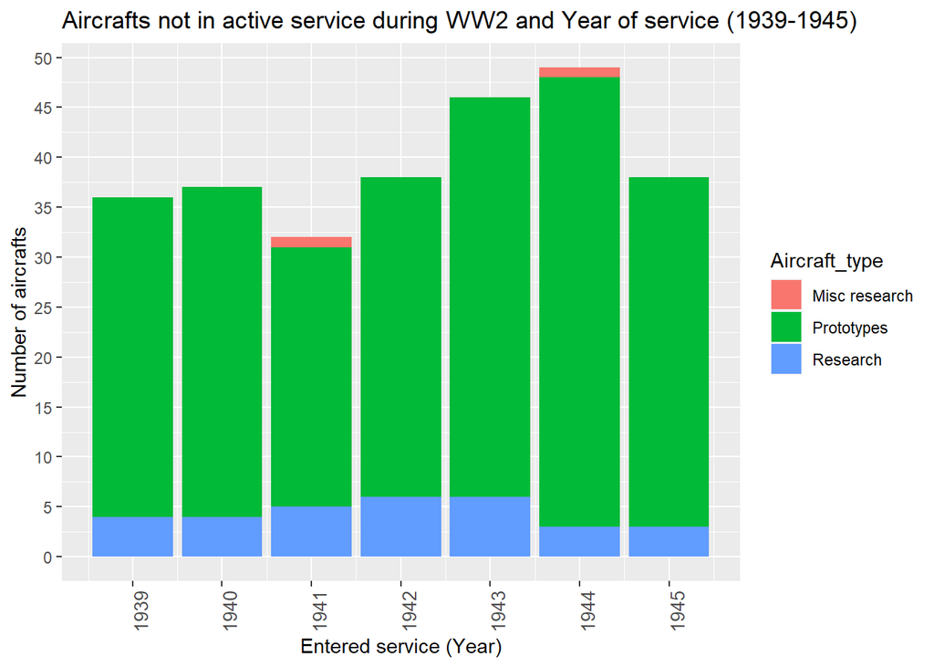

```r
aircrafts_ww2 %>%
  drop_na(Year_service) %>%
  filter(Aircraft_type %in% c("Prototypes", "Research", "Misc research")) %>%
  filter(Year_service %in% c("1939", "1940", "1941", "1942", "1943", "1944", "1945")) %>%
  ggplot(aes(x = Year_service)) +
  geom_bar(aes(fill = Aircraft_type)) +
  labs(title = "Aircrafts not in active service during WW2 and Year of service (1939-1945)",
       y = "Number of aircrafts",
       x = "Entered service (Year)") +
    scale_y_continuous(breaks=seq(0,55,5)) +
    scale_x_continuous(breaks=seq(1939,1945,1)) +
    theme(axis.text.x = element_text(angle = 90)) +
    theme(axis.text.x = element_text(size = 10))
```

From this we can see there was an increase in prototypes from 1938-1945. Many prototypes meant that many aircrafts was also made which makes sense - in war having the best weapons, and therefore aircrafts, was important and therefore there was put a lot of research into aircrafts.

## All Aircrafts and Year in service by Country of Origin

Now I would to visualize the biggest participants of aircrafts in World War 2 by their Year of service and what types of Aircrafts they made:

USA:

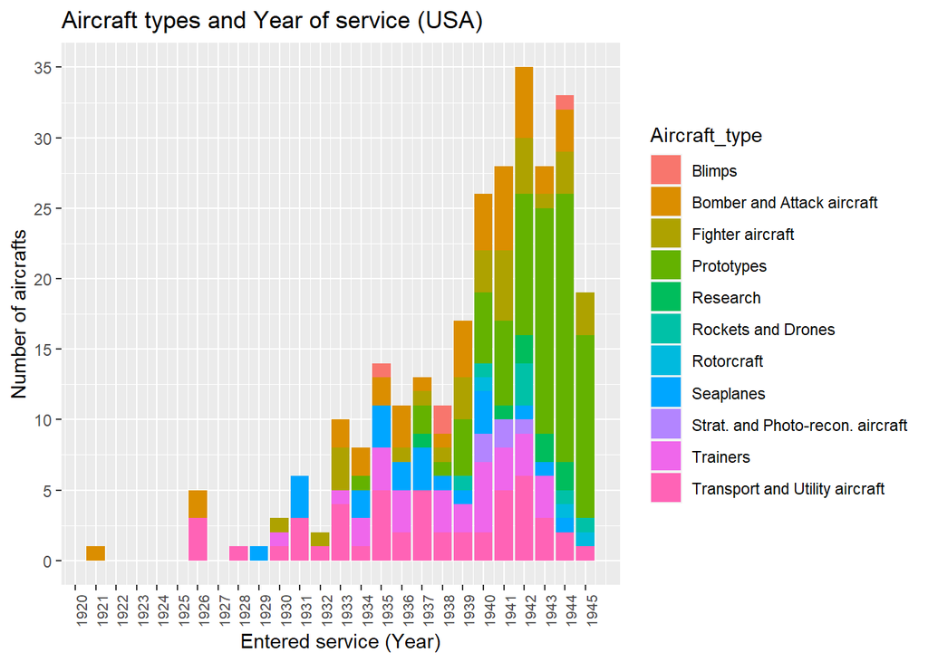

```r
aircrafts_ww2 %>%
  filter(Country %in% c ("US")) %>%
  drop_na(Country) %>%
  drop_na(Year_service) %>%
  ggplot(aes(x = Year_service)) +
  geom_bar(aes(fill = Aircraft_type)) +
  labs(title = "Aircraft types and Year of service (USA)",
       y = "Number of aircrafts",
       x = "Entered service (Year)") +
    scale_y_continuous(breaks=seq(0,40,5)) +
    scale_x_continuous(breaks=seq(1913,1945,1)) +
    theme(axis.text.x = element_text(angle = 90)) +
    theme(axis.text.x = element_text(size = 8))
```

United Kingdom:

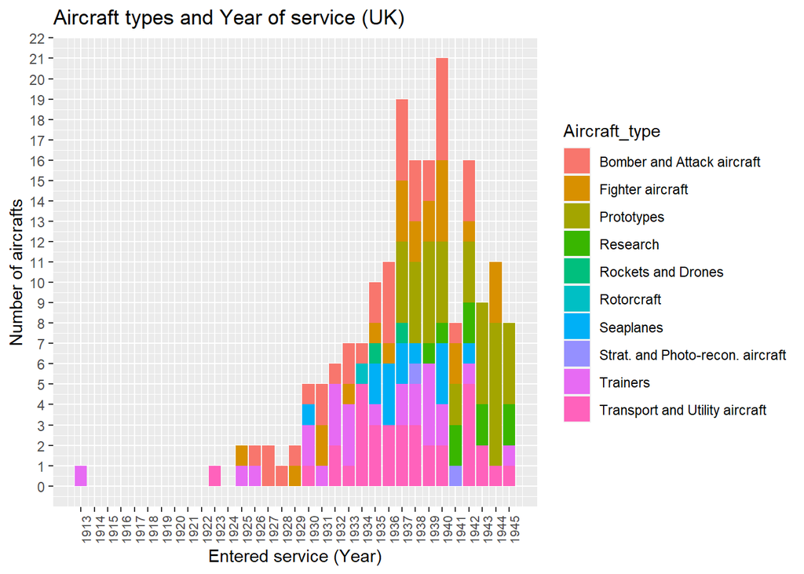

```r
aircrafts_ww2 %>%
  filter(Country %in% c ("UK")) %>%
  drop_na(Country) %>%
  drop_na(Year_service) %>%
  ggplot(aes(x = Year_service)) +
  geom_bar(aes(fill = Aircraft_type)) +
  labs(title = "Aircraft types and Year of service (UK)",
       y = "Number of aircrafts",
       x = "Entered service (Year)") +
    scale_y_continuous(breaks=seq(0,30,1)) +
    scale_x_continuous(breaks=seq(1913,1945,1)) +
    theme(axis.text.x = element_text(angle = 90)) +
    theme(axis.text.x = element_text(size = 8))
```

Germany:

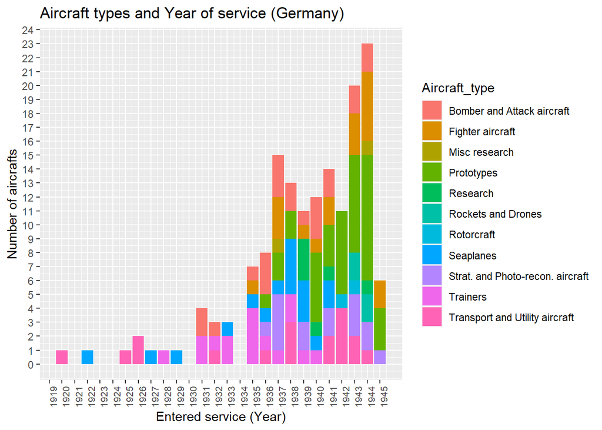

```r
aircrafts_ww2 %>%
  filter(Country %in% c ("Germany")) %>%
  drop_na(Country) %>%
  drop_na(Year_service) %>%
  ggplot(aes(x = Year_service)) +
  geom_bar(aes(fill = Aircraft_type)) +
  labs(title = "Aircraft types and Year of service (Germany)",
       y = "Number of aircrafts",
       x = "Entered service (Year)") +
    scale_y_continuous(breaks=seq(0,30,1)) +
    scale_x_continuous(breaks=seq(1913,1945,1)) +
    theme(axis.text.x = element_text(angle = 90)) +
    theme(axis.text.x = element_text(size = 8))
```

Japan:

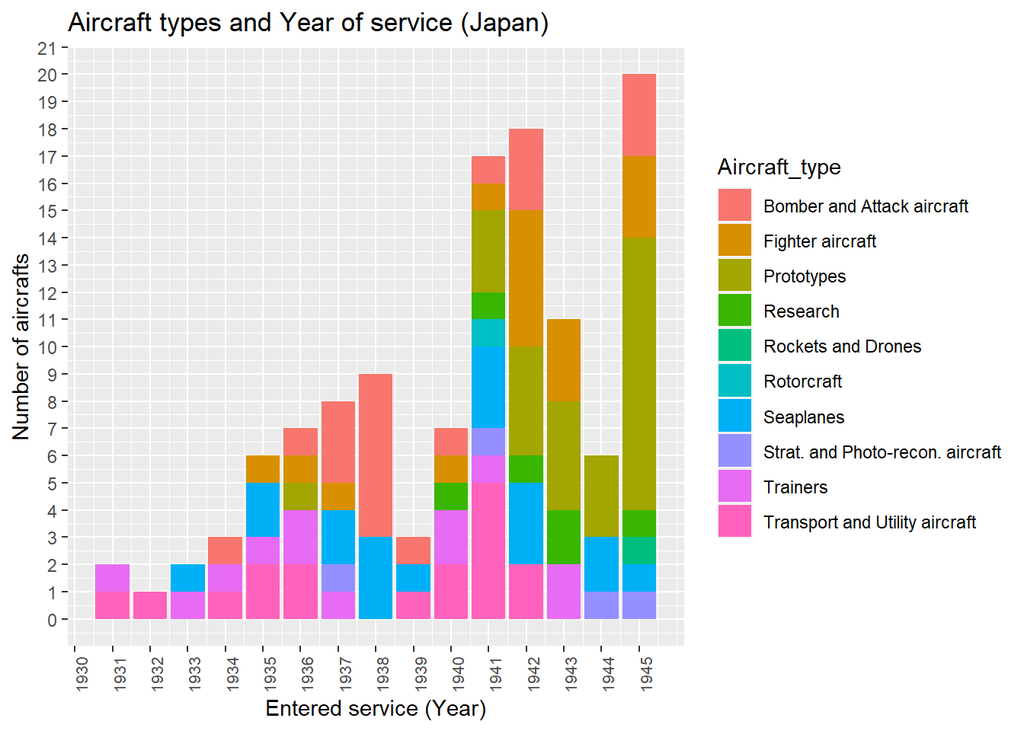

```r
aircrafts_ww2 %>%
  filter(Country %in% c ("Japan")) %>%
  drop_na(Country) %>%
  drop_na(Year_service) %>%
  ggplot(aes(x = Year_service)) +
  geom_bar(aes(fill = Aircraft_type)) +
  labs(title = "Aircraft types and Year of service (Japan)",
       y = "Number of aircrafts",
       x = "Entered service (Year)") +
    scale_y_continuous(breaks=seq(0,30,1)) +
    scale_x_continuous(breaks=seq(1913,1945,1)) +
    theme(axis.text.x = element_text(angle = 90)) +
    theme(axis.text.x = element_text(size = 8))
```

Italy:

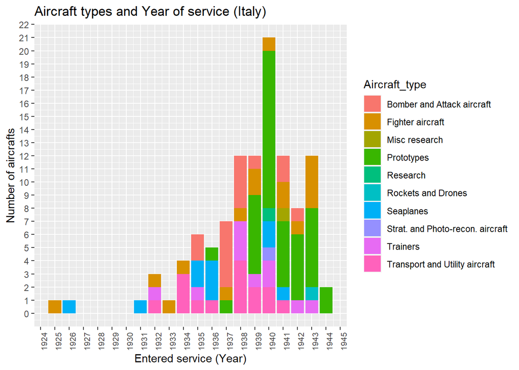

```r
aircrafts_ww2 %>%
  filter(Country %in% c ("Italy")) %>%
  drop_na(Country) %>%
  drop_na(Year_service) %>%
  ggplot(aes(x = Year_service)) +
  geom_bar(aes(fill = Aircraft_type)) +
  labs(title = "Aircraft types and Year of service (Italy)",
       y = "Number of aircrafts",
       x = "Entered service (Year)") +
    scale_y_continuous(breaks=seq(0,30,1)) +
    scale_x_continuous(breaks=seq(1913,1945,1)) +
    theme(axis.text.x = element_text(angle = 90)) +
    theme(axis.text.x = element_text(size = 8))
```

France:

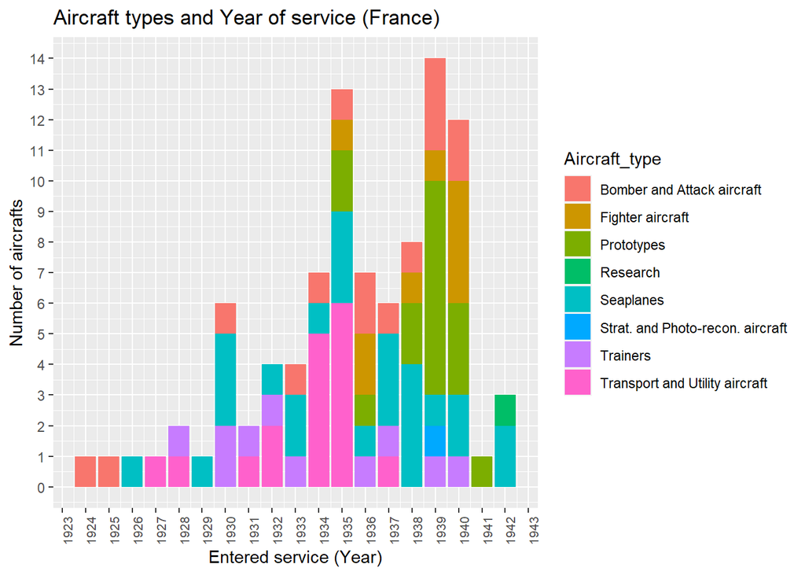

```r
aircrafts_ww2 %>%
  filter(Country %in% c ("France")) %>%
  drop_na(Country) %>%
  drop_na(Year_service) %>%
  ggplot(aes(x = Year_service)) +
  geom_bar(aes(fill = Aircraft_type)) +
  labs(title = "Aircraft types and Year of service (France)",
       y = "Number of aircrafts",
       x = "Entered service (Year)") +
    scale_y_continuous(breaks=seq(0,30,1)) +
    scale_x_continuous(breaks=seq(1913,1945,1)) +
    theme(axis.text.x = element_text(angle = 90)) +
    theme(axis.text.x = element_text(size = 8))
```

USSR:

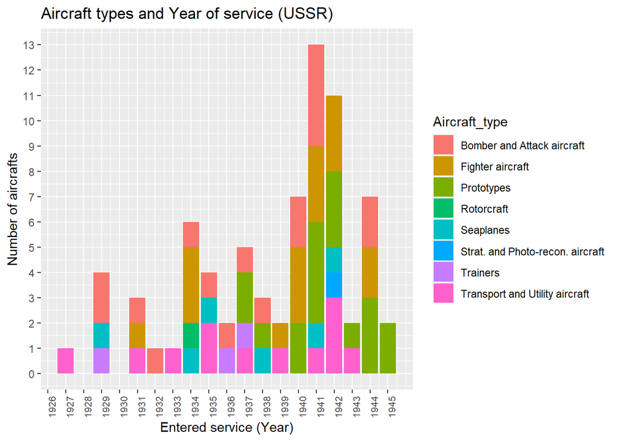

```r
aircrafts_ww2 %>%
  filter(Country %in% c ("USSR")) %>%
  drop_na(Country) %>%
  drop_na(Year_service) %>%
  ggplot(aes(x = Year_service)) +
  geom_bar(aes(fill = Aircraft_type)) +
  labs(title = "Aircraft types and Year of service (USSR)",
       y = "Number of aircrafts",
       x = "Entered service (Year)") +
    scale_y_continuous(breaks=seq(0,20,1)) +
    scale_x_continuous(breaks=seq(1913,1945,1)) +
    theme(axis.text.x = element_text(angle = 90)) +
    theme(axis.text.x = element_text(size = 8))
```